# Benchmark de Arquitectura de Datos - GoiEner

CSV vs Parquet vs DuckDB: rendimiento y tamaño en disco

Author

Alberto Fernandez

Published

June 10, 2026

## Introducción

Una de las decisiones clave de este TFM es la eleccion de la **arquitectura de datos**. En lugar de trabajar con los CSV crudos (un fichero por punto de suministro), se opto por:

1. **Apache Parquet** como formato columnar con compresión ZSTD-9.
2. **Particionado por año** (`year=YYYY/`) para permitir predicate pushdown temporal.
3. **DuckDB** como motor SQL analítico embebido para consultas directas sobre Parquet.
4. **Tablas pre-agregadas** (diaria, mensual, perfiles horarios) para evitar recorrer los ~950M+ registros en cada consulta.

Este capítulo funciona como anexo fuerte de arquitectura: cuantifica si el stack local elegido es suficiente para desarrollar y reproducir el TFM con solvencia. No se plantea como una comparativa universal contra Spark ni como el centro metodologico del trabajo.

## Resultados del benchmark

**Ver código**

```r
bench_file <- path(TABLE_DIR, "benchmark_results.csv")
disk_file  <- path(TABLE_DIR, "benchmark_disk_size.csv")
env_file   <- path(TABLE_DIR, "benchmark_environment.csv")

has_bench <- file_exists(bench_file)
has_disk  <- file_exists(disk_file)
has_env   <- file_exists(env_file)

if (has_bench) {
  bench_results <- read.csv(bench_file)
  cat(sprintf("Experimentos cargados: %d mediciones\n", nrow(bench_results)))
} else {
  cat("No se encontraron resultados. Ejecuta R/07_benchmark/07_benchmark.R primero.\n")
}
```

```
Experimentos cargados: 12 mediciones
```

**Ver código**

```r
if (has_disk) {
  disk_summary <- read.csv(disk_file)
}

if (has_env) {
  bench_env <- read.csv(env_file)
}
```

## Contexto de ejecución

Los tiempos deben leerse como una medición local reproducible sobre este equipo y este dataset. El script no vacía la caché del sistema operativo entre iteraciones; por eso se guardan tanto la primera iteración de la sesión como la mediana caliente de las iteraciones posteriores. Además, DuckDB puede beneficiarse de cachés internas si están habilitadas en la configuración del proyecto.

**Ver código**

```r
if (has_env) {
  env_display <- bench_env |>
    filter(item %in% c(
      "os", "cpu", "logical_cores", "physical_ram_gb",
      "r_version", "duckdb_version", "arrow_version", "bench_version",
      "duckdb_memory_limit", "duckdb_object_cache",
      "iterations_per_experiment", "cache_context",
      "process_peak_working_set_mb", "memory_note"
    )) |>
    mutate(
      item = recode(item,
        os = "Sistema operativo",
        cpu = "CPU",
        logical_cores = "Cores logicos",
        physical_ram_gb = "RAM fisica (GB)",
        r_version = "R",
        duckdb_version = "DuckDB",
        arrow_version = "Arrow",
        bench_version = "bench",
        duckdb_memory_limit = "Limite DuckDB",
        duckdb_object_cache = "Object cache DuckDB",
        iterations_per_experiment = "Iteraciones por experimento",
        cache_context = "Contexto de cache",
        process_peak_working_set_mb = "Pico proceso R (MB)",
        memory_note = "Nota memoria"
      )
    )

  report_table(
    env_display,
    caption = "Hardware, versiones y contexto de cache del benchmark.",
    col.names = c("Variable", "Valor")
  )
}
```

Table 1: Hardware, versiones y contexto de cache del benchmark.

| Variable | Valor |
| --- | --- |
| R | 4.5.1 |
| Sistema operativo | Microsoft Windows 11 Home \| 10.0.26200 |
| CPU | 12th Gen Intel(R) Core(TM) i7-12650H |
| Cores logicos | 16 |
| RAM fisica (GB) | 31.7 |
| DuckDB | 1.4.4 |
| Arrow | 23.0.1.1 |
| bench | 1.1.4 |
| Limite DuckDB | 10GB |
| Object cache DuckDB | TRUE |
| Iteraciones por experimento | 5 |
| Contexto de cache | No se vacia la cache del sistema operativo entre iteraciones. first_iter_s aproxima la primera ejecucion de la sesion y warm_mediana_s resume iteraciones 2-5. DuckDB object cache configurada: TRUE. |
| Pico proceso R (MB) | 5382.2 |
| Nota memoria | mem_alloc_mb es memoria asignada estimada por bench; process_peak_working_set_mb es el pico del proceso R completo en Windows. |

## 1. Comparativa de rendimiento

**Ver código**

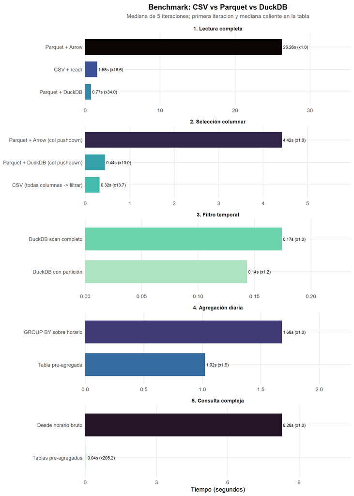

Figure 1: Tiempo de ejecución por experimento y método. El speedup se calcula respecto al método más lento.

```r
if (has_bench) {
  tic("benchmark-viz")

  p_bench <- bench_results |>
    mutate(
      label = sprintf("%.2fs (x%.1f)", mediana_s, speedup),
      metodo = forcats::fct_reorder(metodo, mediana_s)
    ) |>
    ggplot(aes(x = metodo, y = mediana_s, fill = metodo)) +
    geom_col(show.legend = FALSE, width = 0.7) +
    geom_text(aes(label = label), hjust = -0.05, size = 3) +
    coord_flip() +
    facet_wrap(~experimento, scales = "free", ncol = 1) +
    scale_fill_viridis_d(option = "mako", direction = -1) +
    scale_y_continuous(expand = expansion(mult = c(0, 0.35))) +
    labs(
      title = "Benchmark: CSV vs Parquet vs DuckDB",
      subtitle = "Mediana de 5 iteraciones; primera iteracion y mediana caliente en la tabla",
      x = NULL, y = "Tiempo (segundos)"
    ) +
    theme_goiener() +
    theme(strip.text = element_text(face = "bold"))

  print(p_bench)
  toc("benchmark-viz")
}
```

### Tabla detallada

**Ver código**

```r
if (has_bench) {
  bench_display <- bench_results |>
    select(experimento, metodo, first_iter_s, warm_mediana_s, mediana_s,
           speedup, mem_alloc_mb) |>
    mutate(
      first_iter_s = round(first_iter_s, 3),
      warm_mediana_s = round(warm_mediana_s, 3),
      mediana_s = round(mediana_s, 3),
      speedup = round(speedup, 1),
      mem_alloc_mb = round(mem_alloc_mb, 1)
    )

  report_table(bench_display,
    caption = "Resultados del benchmark. La primera iteracion aproxima ejecucion fria de sesion; la mediana caliente resume iteraciones 2-5.",
    col.names = c("Experimento", "Método", "Primera iter. (s)",
                  "Mediana caliente (s)", "Mediana total (s)",
                  "Speedup", "Mem. asignada (MB)"))
}
```

Resultados del benchmark. La primera iteracion aproxima ejecucion fria de sesion; la mediana caliente resume iteraciones 2-5.

| Experimento | Método | Primera iter. (s) | Mediana caliente (s) | Mediana total (s) | Speedup | Mem. asignada (MB) |
| --- | --- | --- | --- | --- | --- | --- |
| 1. Lectura completa | CSV + readr | 1.639 | 1.575 | 1.582 | 16.6 | 215.7 |
| 1. Lectura completa | Parquet + Arrow | 26.264 | 25.938 | 26.264 | 1.0 | 16.2 |
| 1. Lectura completa | Parquet + DuckDB | 0.773 | 0.772 | 0.773 | 34.0 | 0.2 |
| 2. Selección columnar | CSV (todas columnas -> filtrar) | 0.323 | 0.325 | 0.324 | 13.7 | 37.5 |
| 2. Selección columnar | Parquet + Arrow (col pushdown) | 4.399 | 4.447 | 4.422 | 1.0 | 6.3 |
| 2. Selección columnar | Parquet + DuckDB (col pushdown) | 0.449 | 0.443 | 0.443 | 10.0 | 12.3 |
| 3. Filtro temporal | DuckDB scan completo | 0.167 | 0.175 | 0.174 | 1.0 | 0.0 |
| 3. Filtro temporal | DuckDB con partición | 0.141 | 0.144 | 0.143 | 1.2 | 0.0 |
| 4. Agregación diaria | GROUP BY sobre horario | 1.737 | 1.619 | 1.681 | 1.0 | 137.4 |
| 4. Agregación diaria | Tabla pre-agregada | 1.025 | 0.970 | 1.025 | 1.6 | 137.4 |
| 5. Consulta compleja | Desde horario bruto | 8.265 | 8.278 | 8.278 | 1.0 | 0.0 |
| 5. Consulta compleja | Tablas pre-agregadas | 0.040 | 0.040 | 0.040 | 205.2 | 0.0 |

## 2. Análisis por experimento

### Exp 1: Lectura completa

La lectura de una muestra de 100 CSV con `readr` se compara con la lectura equivalente en Parquet (Arrow) y DuckDB. Para que la comparacion sea justa, las tres rutas devuelven el mismo resultado (un conteo de filas tras filtrar por la lista de `user_id` de la muestra) — sin materializar las filas en R, que penalizaria el motor que ya ha hecho el trabajo correctamente.

**Ver código**

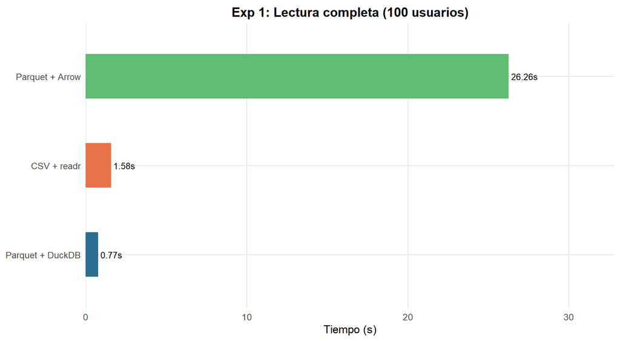

```r
if (has_bench) {
  exp1 <- bench_results |> filter(grepl("Lectura", experimento))

  if (nrow(exp1) > 0) {
    p_exp1 <- exp1 |>
      mutate(metodo = forcats::fct_reorder(metodo, mediana_s)) |>
      ggplot(aes(x = metodo, y = mediana_s, fill = metodo)) +
      geom_col(show.legend = FALSE, width = 0.5) +
      geom_text(aes(label = sprintf("%.2fs", mediana_s)), hjust = -0.1, size = 3.5) +
      coord_flip() +
      scale_fill_manual(values = c(PAL_MAIN, PAL_ACCENT, "#5EBD72")) +
      scale_y_continuous(expand = expansion(mult = c(0, 0.25))) +
      labs(title = "Exp 1: Lectura completa (100 usuarios)",
           x = NULL, y = "Tiempo (s)") +
      theme_goiener()

    p_exp1
  }
}
```

### Exp 3: Filtro temporal (partition pruning)

**Ver código**

```r
if (has_bench) {
  exp3 <- bench_results |> filter(grepl("Filtro", experimento))

  if (nrow(exp3) > 0) {
    cat("DuckDB con particionado Hive puede saltar directamente a la carpeta year=2020,\n")
    cat("evitando leer datos de otros años. Esto se traduce en:\n\n")

    for (i in seq_len(nrow(exp3))) {
      cat(sprintf("  %s: %.3f s (x%.1f)\n",
                  exp3$metodo[i], exp3$mediana_s[i], exp3$speedup[i]))
    }
  }
}
```

```
DuckDB con particionado Hive puede saltar directamente a la carpeta year=2020,
evitando leer datos de otros años. Esto se traduce en:

  DuckDB scan completo: 0.174 s (x1.0)
  DuckDB con partición: 0.143 s (x1.2)
```

### Exp 4: Agregación desde horario vs tabla pre-agregada

**Ver código**

```r
if (has_bench) {
  exp4 <- bench_results |> filter(grepl("Agregación", experimento))

  if (nrow(exp4) > 0) {
    cat("La tabla pre-agregada evita re-recorrer los registros horarios:\n\n")

    for (i in seq_len(nrow(exp4))) {
      cat(sprintf("  %s: %.3f s (x%.1f)\n",
                  exp4$metodo[i], exp4$mediana_s[i], exp4$speedup[i]))
    }

    cat("\nEste es el patrón de diseno más impactante: materializar las agregaciones\n")
    cat("que se usan repetidamente en el EDA y en el forecasting.\n")
  }
}
```

```
La tabla pre-agregada evita re-recorrer los registros horarios:

  GROUP BY sobre horario: 1.681 s (x1.0)
  Tabla pre-agregada: 1.025 s (x1.6)

Este es el patrón de diseno más impactante: materializar las agregaciones
que se usan repetidamente en el EDA y en el forecasting.
```

## 3. Tamaño en disco

**Ver código**

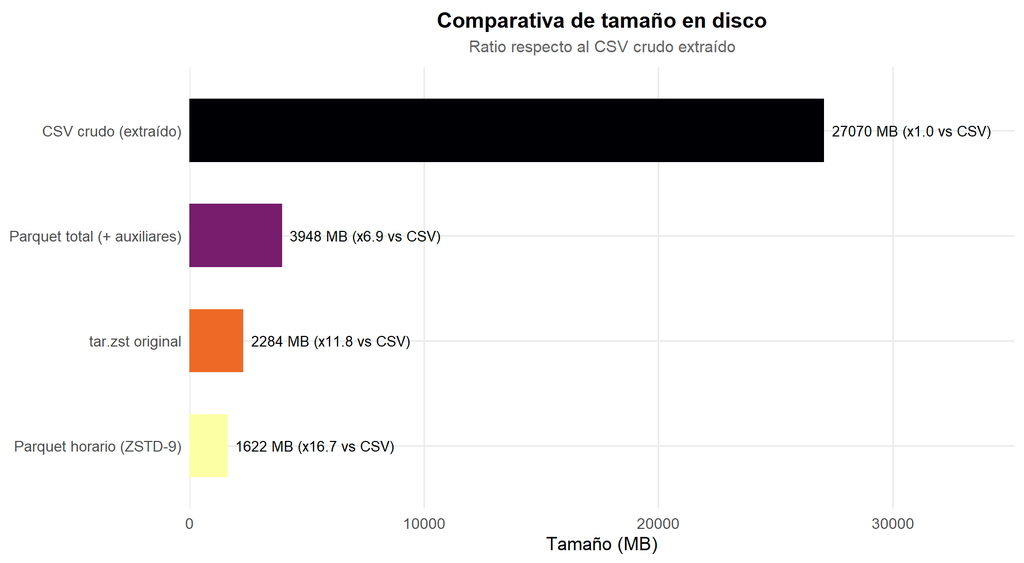

Figure 3: Comparativa de tamaño en disco entre formatos.

```r
if (has_disk) {
  tic("disk-size")

  p_disk <- disk_summary |>
    filter(!is.na(MB)) |>
    mutate(
      formato = forcats::fct_reorder(formato, MB),
      label = sprintf("%.0f MB (x%.1f vs CSV)", MB, ratio_vs_csv)
    ) |>
    ggplot(aes(x = formato, y = MB, fill = formato)) +
    geom_col(show.legend = FALSE, width = 0.6) +
    geom_text(aes(label = label), hjust = -0.05, size = 3.5) +
    coord_flip() +
    scale_fill_viridis_d(option = "inferno", direction = -1) +
    scale_y_continuous(expand = expansion(mult = c(0, 0.3))) +
    labs(
      title = "Comparativa de tamaño en disco",
      subtitle = "Ratio respecto al CSV crudo extraído",
      x = NULL, y = "Tamaño (MB)"
    ) +
    theme_goiener()

  print(p_disk)

  report_table(disk_summary |> mutate(across(where(is.numeric), ~round(., 1))),
    caption = "Tamaño en disco por formato",
    col.names = c("Formato", "Bytes", "MB", "GB", "Ratio vs CSV"))

  toc("disk-size")
}
```

[output not shown]

## 4. Discusion

La eleccion de arquitectura no es un detalle técnico menor: tiene un impacto directo en la experiencia de desarrollo y en la viabilidad de iterar sobre los datos. El resultado se interpreta como **suficiente para un entorno local reproducible**: Parquet, DuckDB y tablas pre-agregadas permiten ejecutar el TFM sin desplegar Spark, reduciendo complejidad operativa y manteniendo trazabilidad.

**Ventajas del stack Parquet + DuckDB:**

En este tamaño de datos, Spark no aporta una ventaja practica que compense su coste de instalacion, configuracion y reproducibilidad. La decision no invalida Spark como tecnologia: si el dataset creciera 100x, si aparecieran cargas concurrentes multiusuario o si el procesamiento tuviera que distribuirse entre nodos, Spark podria volver a tener sentido.

**Limitaciones:**

- La transformación inicial (CSV -> Parquet) requiere una ejecución única que puede tardar bastante (~30-60 min en este dataset).
- DuckDB tiene un límite de memoria configurable (aquí 10GB), que puede ser insuficiente para operaciones de join sobre el dataset completo sin particionado.
- Las consultas ad-hoc sobre el Parquet horario completo siguen siendo lentas; la pre-agregación es necesaria para un flujo de trabajo interactivo.
- Las mediciones dependen del hardware, versiones de librerias y cache del sistema operativo; por tanto, no deben leerse como benchmark universal.
- La memoria por metodo se reporta como memoria asignada por `bench`; el pico del proceso R se muestra como contexto de ejecucion cuando el sistema operativo permite medirlo de forma directa.

### Síntesis del benchmark

**1. La arquitectura no es una elección estética, es una restricción de proyecto.** Un TFM tiene que ser reproducible por un tribunal en una máquina personal sin pedir cuentas de nube ni clusters HPC. El stack Parquet + DuckDB cumple esa restricción y la cumple bien: el orquestador ejecuta extremo a extremo (00 → 07) en horas, no en días, y los outputs son determinísticos dado el mismo input y los mismos semilleros.

**2. Cuándo dejaría de tener sentido este stack.** Si el dataset creciera ~100x (decenas de miles de millones de registros horarios), si aparecieran cargas concurrentes multiusuario reales (no solo desarrollo individual) o si el procesamiento tuviera que distribuirse entre nodos con SLA estricto, Spark o un motor distribuido volverían a ser la opción correcta. Mientras estemos en el orden de magnitud actual, no aportan ventaja práctica que compense su coste operativo.

**3. La pre-agregación es la palanca de mayor impacto.** El benchmark muestra que las tablas pre-calculadas (diaria, mensual, perfiles horarios) ahorran órdenes de magnitud de tiempo frente a recorrer los ~950M registros horarios cada vez. Esto no es Parquet vs CSV: es el patrón de “calcular una vez, leer muchas veces” aplicado a una cartera grande. Cualquier proyecto similar debería empezar por ahí, independientemente del motor que use.

**4. La trazabilidad y la auditabilidad son resultados, no efectos secundarios.** El benchmark queda registrado en `benchmark_results.csv`, los tiempos del orquestador en `pipeline_timings.csv` y el entorno (versiones, hardware) en `benchmark_environment.csv`. Eso significa que la afirmación “el TFM se reproduce en X horas” es verificable, no una promesa. Si en una ejecución futura el tiempo se duplica, sabremos qué fase es responsable y con qué hardware se comparó.

**5. Limitaciones honestas del propio benchmark.** Las mediciones dependen del hardware, del sistema operativo y del cache. Repetir el benchmark en una máquina distinta dará números distintos. Lo que se sostiene es el orden de magnitud y la jerarquía relativa entre formatos y patrones de acceso, no los segundos exactos.

**Implicación final.** El stack elegido permite hacer un TFM ambicioso (clima AEMET, clustering, forecasting con intervalos, dashboard Astro) sin depender de infraestructura cara o difícil de auditar. La decisión arquitectónica es defendible no porque Parquet sea “mejor” en abstracto, sino porque resuelve esta combinación específica de volumen, restricciones y necesidad de reproducibilidad de forma medible.

## Resumen de tiempos

**Ver código**

```r
timing_df <- data.frame(
  chunk = names(get_timings()),
  segundos = vapply(get_timings(), function(x) if (!is.null(x$elapsed)) unname(x$elapsed) else NA_real_, numeric(1)),
  row.names = NULL
)
timing_df <- timing_df[!is.na(timing_df$segundos), ]
timing_df <- timing_df[order(-timing_df$segundos), ]
timing_df$pct <- round(100 * timing_df$segundos / sum(timing_df$segundos), 1)
report_table(timing_df, digits = 1, col.names = c("Chunk", "Segundos", "% del total"))
```

| Chunk | Segundos | % del total |
| --- | --- | --- |
| benchmark-viz | 0.5 | 73.1 |
| disk-size | 0.2 | 26.9 |